# 第6回 整理集計①：地域指標

## 失敗例 貼った人口と引いた人口

貼る（行の順で合わせる）  
D2（北海道）に 14038  
東京都の人口。エラーは出ない

引く（県名で合わせる）  
D2（北海道）に 5140  
同じ県名の行の人口

| 都道府県 | 貼った人口 | 引いた人口 |
| --- | --- | --- |
| 北海道 | 14,038 | **5,140** |
| 青森県 | 9,232 | **1,204** |
| 東京都 | 2,550 | **14,038** |

貼りたくなるのは、どちらにも同じ 47 県が並ぶから。単位は千人

## 見つからない 3 つの原因

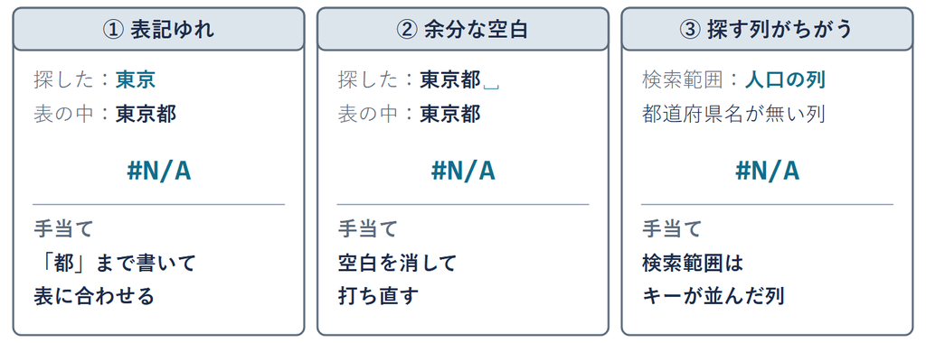

A14 の「東京」は ① の表記ゆれ。印が出れば、直す所が分かる

## 結合

用語

**結合**：共通のキーで、表と表を 1 つにすること

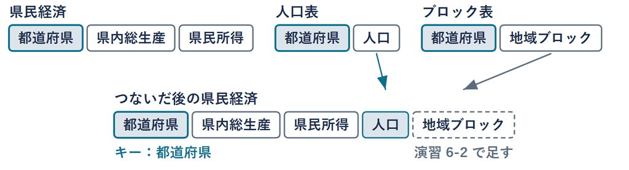

ゼミのアンケートと名簿も、学籍番号で 1 つの表にできる

## 演習 6-2 地域ブロックの列

演習 6-2

ブロック表から地域ブロックを引くと、沖縄県の行は何か

1. **作る場所**：「県民経済」の E1 に 地域ブロック。D2 の式を数式バーでコピーし、  
   E2 に貼る。貼った直後は、人口と同じ数が並ぶ。2 で直すと変わる
2. **変える所**：表の名前 2 か所を ブロック表 に、  
   戻り範囲の列名 1 か所を 地域ブロック に
3. **考える問い**：沖縄県（48 行目）の地域ブロックは何か。先に予想する
4. **書く**：答えを「地域」の N4 に打つ。東京都が関東なら式は正しい

✋ 動画を止めて 3 分。N4 に打ったら再生に戻る

## 演習 6-2 の答えの例

`=XLOOKUP([@都道府県],`← 検索値

`ブロック表[都道府県],`← 検索範囲

`ブロック表[地域ブロック])`← 戻り範囲

| 都道府県 | 地域ブロック |
| --- | --- |
| 北海道 | 北海道 |
| 青森県 | 東北 |
| 東京都 | 関東 |
| 沖縄県 | **九州** |

- **N4**：九州 と打つ
- **変えた所**：表の名前 2 か所と、戻り範囲の列名

## まとめ

- **キー**：行を 1 つに決める、重複しない目印の列
- **XLOOKUP**：キーで探し、同じ行の値を返す。並び順を問わない
- **`#N/A`**：見つからない印。貼ったときと違い、黙って間違えない
- **結合**：共通のキーで、表を 1 つにする

3 つの表が 1 つになった。この 47 行から、何が言えるのか  
これを次のトピックで見る

経済データ入門

第6回 — Topic04

1 人当たり指標とフィルタ

大きさと 1 人当たりは、別の問い

## この回の道のりと「県民経済」シート

1

出所と範囲

2

取り込みと型

演習 6-1

文字にした東京都

3

キーで結合

演習 6-2

地域ブロック

4

並べて絞る

演習 6-3

大阪府の 1 人当たり

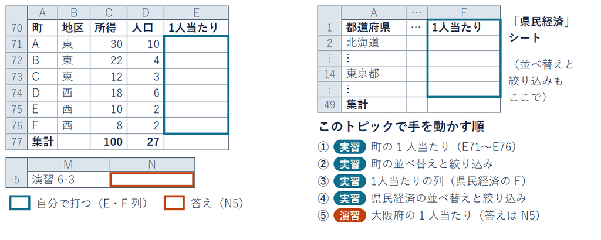

「地域」の E71〜E76・N5 と、「県民経済」の F 列

## 大きさと豊かさ

県民経済の表に、  
県内総生産・県民所得・人口・地域ブロックがそろった  
「どの県が豊かか」を言いたい。でも大きい県は、  
人が多いだけかもしれない  
人の多さをならして比べられないか。  
関東は全体のどれくらいか

- **ならす**：合計を人数で割って、1 人分にそろえる
- **絞る**：表は 1 つのまま、見たい行だけを表示する

まず、6 つの町で考える

## たしかめ 町 A の 1 人当たり

所得がいちばん大きい町 A は  
1 人当たりでも、いちばんか

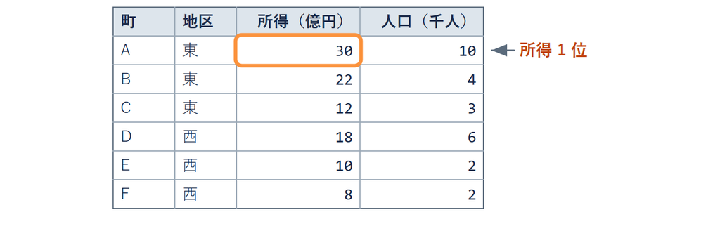

1

**いちばん**

2

**いちばんではない**

**サンプルデータ**：架空の 6 つの町（lec6-exercise.xlsx の A70:E77）

## 割り算と単位

[figure not shown]

割った 3 は「10 万円が 3 つ」。10 倍して、30 万円

## 6 つの町の 1 人当たり

[figure not shown]

**サンプルデータ**：同じ 6 町（lec6-exercise.xlsx の A70:E77）

答えは 2 番。所得 1 位の A は、全体の 37.0 より低い

全体の 37.0 は、6 つの平均 40.8 とは別

## 1 人当たりの式

用語

**1 人当たり**：合計を人数で割って、1 人分にならした数

人の多さをならして比べる。  
億円 ÷ 千人は 10 万円のものさしなので、10 倍して万円に

公式

1 人当たり ＝ 所得 ÷ 人口 × 10

今回は `=[@所得]/[@人口]*10`。町 A は 30 ÷ 10 × 10 ＝ 30

## 町の 1 人当たりの式

1. **式**：E71 に 1 人当たりの式  
   （数式バーのとおり）
2. **広がる**：Enter で E76 まで  
   同じ式が入る
3. **見る**：E71 の 30 は  
   町 A の 30 ÷ 10 × 10

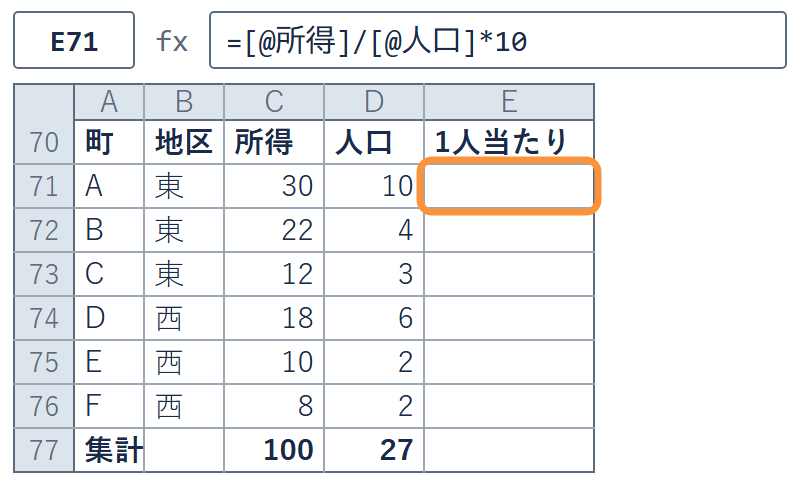

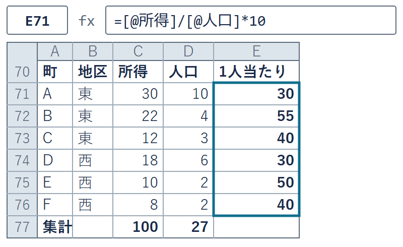

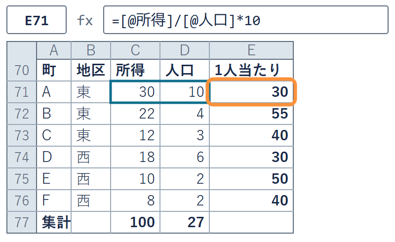

lec6-exercise.xlsx「地域」の E71〜E76 が 30・55・40・30・50・40

✋ 動画を止めて STEP 1〜3 を進め、E76 が 40 なら再生に戻る

## 所得の大きい順

[figure not shown]

**サンプルデータ**：同じ 6 町（lec6-exercise.xlsx の A70:E77）

所得の ▼ から「降順」を選ぶと、行が丸ごと動く

## たしかめ 東に絞った集計行

地区が「東」の町だけを表示すると  
所得の集計行は、どうなるか

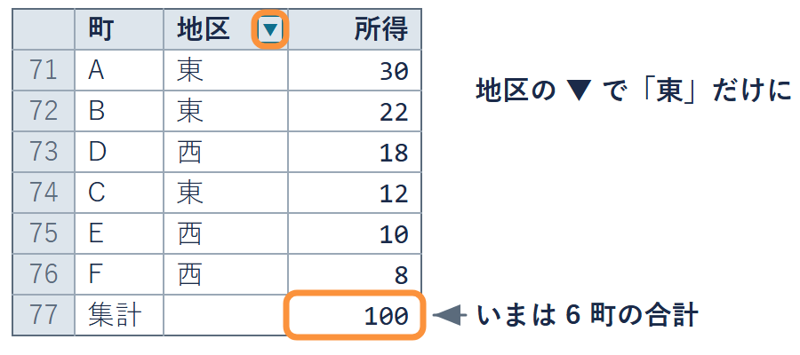

1

**100 のまま**

2

**東の 3 町の合計**

3

**空欄**

**サンプルデータ**：同じ 6 町（lec6-exercise.xlsx の A70:E77）

## 東に絞った集計行

[figure not shown]

**サンプルデータ**：同じ 6 町（lec6-exercise.xlsx の A70:E77）

西の 3 町は、隠れただけ。答えは 2 番

## 降順とフィルタ

用語

**降順**：大きい順に並べること。小さい順は昇順

**フィルタ**：条件に合う行だけを表示すること

**集計行**：いま表示されている行だけを足す

表は変えずに、見え方だけ変える。ほかの行は隠れるだけ

戻すときは、▼ の「"地区" からフィルターをクリア」か「（すべて選択）」

## 町の並べ替えと絞り込み

1. **並べる**：所得の ▼ で  
   「降順」を選ぶ
2. **絞る**：地区の ▼ で  
   「東」だけにチェック
3. **見る**：C77 が 64  
   （すべて選択）に戻すと 100

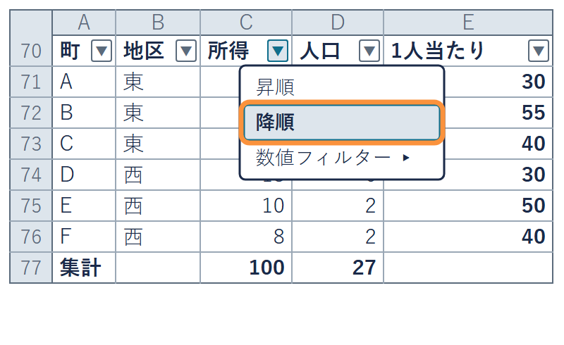

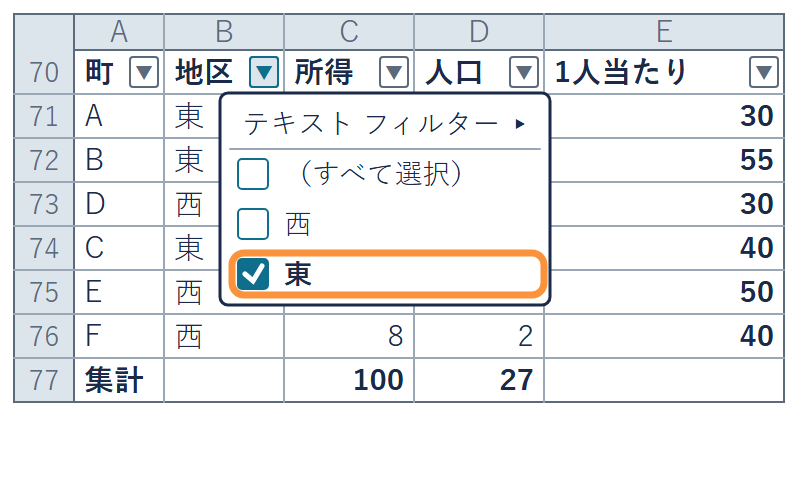

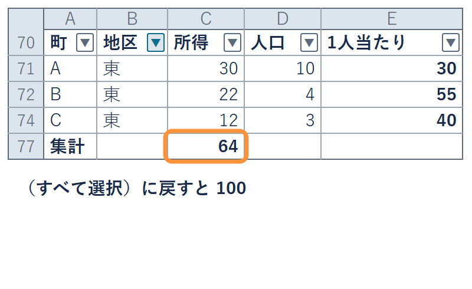

lec6-exercise.xlsx「地域」の C77 が 64 になり、戻すと 100

✋ 動画を止めて STEP 1〜3 を進め、C77 が 100 に戻ったら再生に戻る

## 1 人当たり県民所得

今度は 47 県で、同じ手順を  
県民所得は、その県に住む人と企業が受け取った額

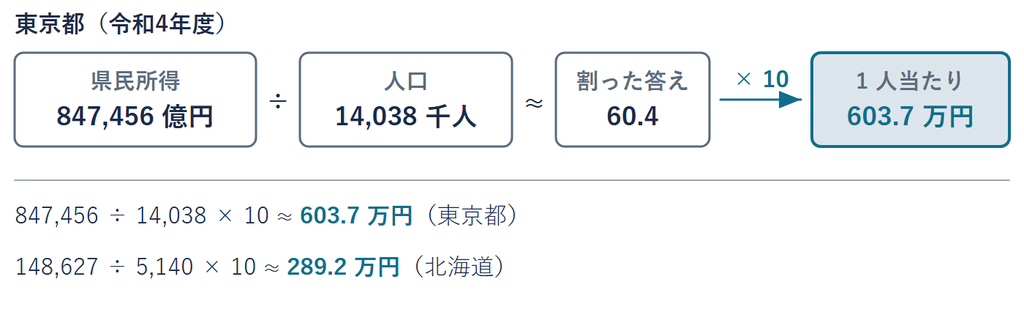

**出典**：内閣府「県民経済計算」総括表・令和4年度

個人の給与ではない。企業の所得も、子どもの人数も入る

## 県民経済の 1 人当たりの式

1. **式**：「県民経済」の F1 に  
   1人当たり、F2 に下の式  
   表はすぐ右の列にだけ広がるので  
   E 列が空なら、先に演習 6-2 を
2. **広がる**：Enter で 47 行に  
   桁が長いまま入る
3. **桁**：F 列を選び、`Ctrl + 1` で  
   数値・小数 1 桁  
   Mac では ⌘ + 1

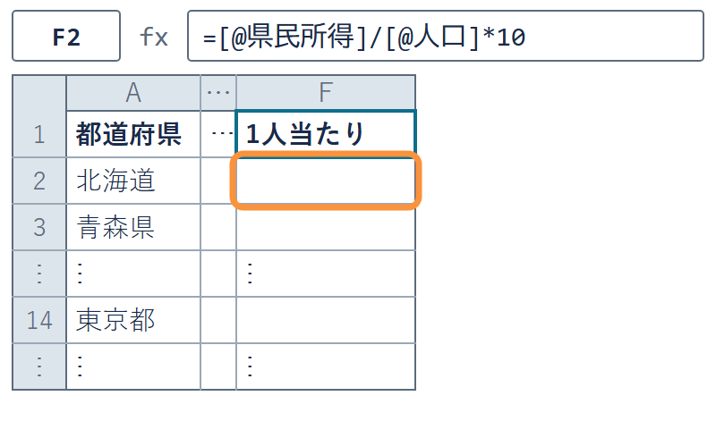

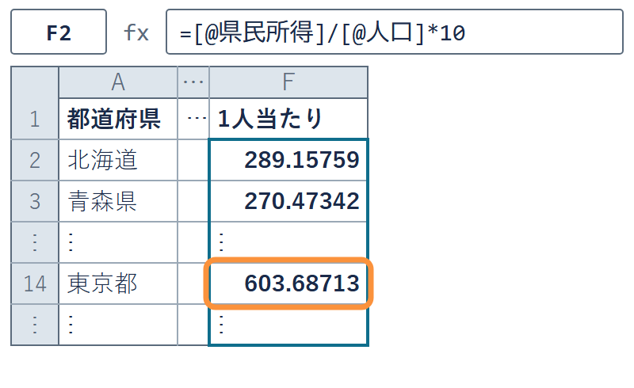

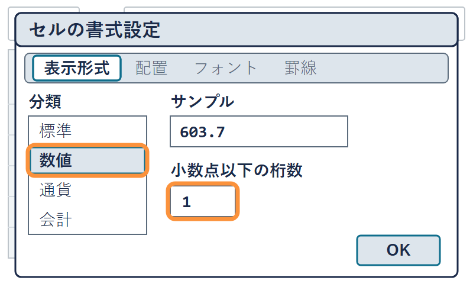

`=[@県民所得]/[@人口]*10` で F14（東京都）が 603.7

✋ 動画を止めて STEP 1〜3 を進め、F14 が 603.7 なら再生に戻る

## 県内総生産の並べ替えと絞り込み

1. **並べる**：県内総生産の ▼  
   で「降順」  
   いちばん上が東京都、  
   その下が大阪府
2. **絞る**：地域ブロックの ▼ で  
   「関東」だけにチェック
3. **見る**：7 行になり B49 が 2,354,030  
   （すべて選択）に戻すと 5,959,196

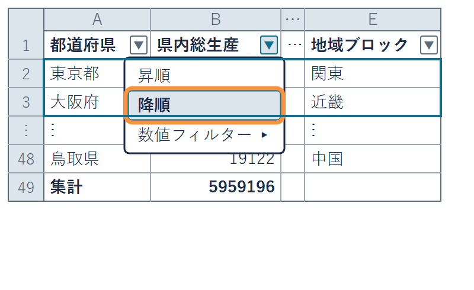

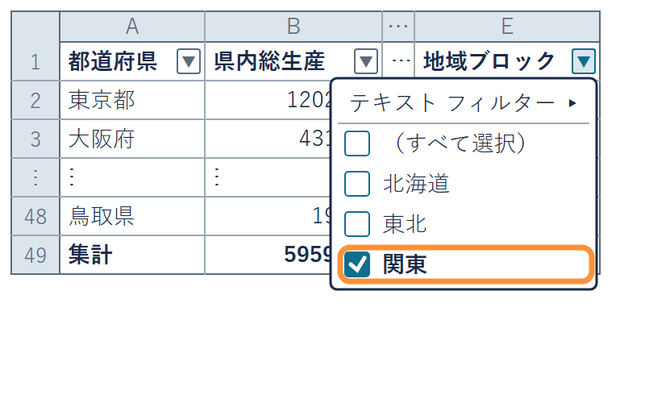

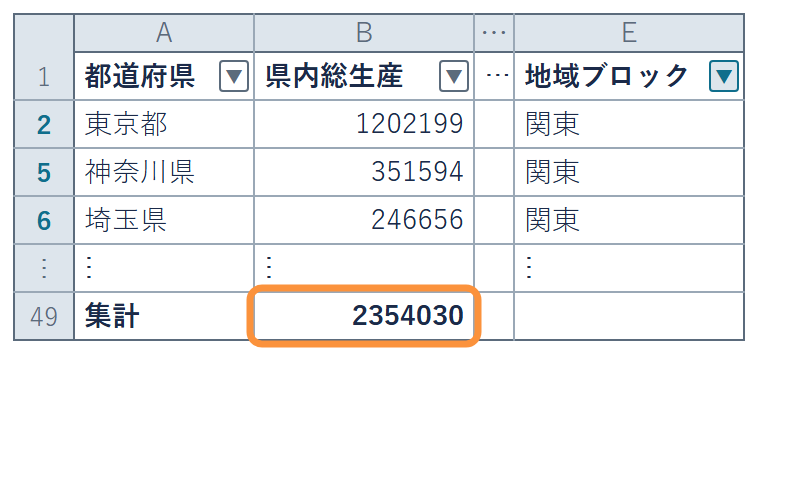

絞ると、関東 7 都県だけの合計が集計行に出る

✋ 動画を止めて STEP 1〜3 を進め、B49 が 5,959,196 に戻ったら再生に戻る

## 関東の割合

[figure not shown]

**出典**：内閣府「県民経済計算」総括表・令和4年度

関東は約 235 兆円、47 県は約 596 兆円。  
県の数では 7 ÷ 47＝約 15%

関東は 2,354,030 ÷ 5,959,196 ≈ 39.5%＝約 4 割

## 失敗例 解除し忘れの合計

絞ったまま読む  
集計行の 2,354,030 を  
47 県の合計として写す

解除してから読む  
（すべて選択）に戻すと  
集計行は 5,959,196

- **隠れた行**：消えていない。▼ の形が変わっていたら、絞り込み中
- **確かめ方**：行番号が飛んでいないか、集計行の値を見る
- **写し違えると**：47 県の合計を、約 360 兆円も小さく読む

絞ったら、解除してから全体を読む

## 演習 6-3 大阪府の 1 人当たり

演習 6-3

大阪府の 1 人当たり県民所得は、  
47 県全体の 344.9 万円より高いか

1. **見る場所**：「県民経済」の F 列。並べ替えたあとも、県名で探す
2. **考える問い**：大阪府は県内総生産で 2 位。先に、高いか低いかを予想する
3. **全体の 344.9**：47 県の県民所得の合計 ÷ 人口の合計 × 10
4. **書く**：大阪府の 1 人当たりを「地域」の N5 に打つ

✋ 動画を止めて 3 分。N5 に打ったら再生に戻る

## 演習 6-3 の答えの例

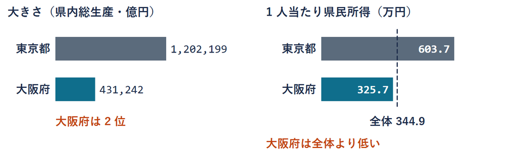

N5 は **325.7**、全体より低い。  
大阪府は人口も 3 位で、所得 1 位の町 A と同じ形

読み分け

経済が大きい県と、1 人当たりが高い県は、  
同じ問いへの答えではない

## まとめ

- **1 人当たり**：合計を人数でならす。億円 ÷ 千人は × 10 で万円
- **降順**：大きい順に並べる。行が丸ごと動く
- **フィルタ**：見たい行だけを表示する。集計行は表示行だけを足す
- **読み分け**：大きさと 1 人当たりは、別の問い

47 行の山が「関東で約 4 割」という 1 行になった  
どの数字で語るかは、何を知りたいかで決まる  
取り込む・つなぐ・絞るの 3 段が、この 1 冊にそろった